# BIA Project Pyspark

# KMeans clustering: PCA visualization + profiling + intra-distance table

Rebuild a numeric features vector from available columns:

- compute cluster centers from data
- compute intra_cluster_distance
- PCA for visualization
- profiling table

```python
from pyspark.ml.feature import VectorAssembler, StandardScaler, PCA
from pyspark.ml.functions import vector_to_array
from pyspark.sql import functions as F

KMEANS_PREDS = "gs://big-data-project-481305-flightdelay/airline/clustering/kmeans_k5/sample10_pred/"
df0 = spark.read.parquet(KMEANS_PREDS)

# 1) numeric cols
num_cols = [
    "CONCURRENT_FLIGHTS","NUMBER_OF_SEATS","PLANE_AGE",
    "PRCP","SNOW","SNWD","TMAX","AWND",
    "MONTH","DAY_OF_WEEK","DISTANCE_GROUP"
]
num_cols = [c for c in num_cols if c in df0.columns]

df = df0.fillna({c: 0 for c in num_cols})

# 2) assemble + scale
assembler = VectorAssembler(inputCols=num_cols, outputCol="num_vec")
df = assembler.transform(df)

scaler = StandardScaler(inputCol="num_vec", outputCol="features_std", withMean=True, withStd=True)
df = scaler.fit(df).transform(df)

VEC_COL = "features_std"
CLUSTER_COL = "cluster"

# IMPORTANT: create df_arr
df_arr = df.withColumn("feat_arr", vector_to_array(F.col(VEC_COL)))

# 3) Compute cluster centers correctly (across rows) via posexplode
centers_long = df_arr.select(CLUSTER_COL, F.posexplode("feat_arr").alias("pos", "val"))

centers_stats = (centers_long
                 .groupBy(CLUSTER_COL, "pos")
                 .agg(F.avg("val").alias("mean_val")))

centers_df = (centers_stats
              .groupBy(CLUSTER_COL)
              .agg(F.sort_array(F.collect_list(F.struct("pos","mean_val"))).alias("tmp"))
              .withColumn("center_arr", F.transform("tmp", lambda s: s["mean_val"]))
              .drop("tmp"))

# 4) Join centers back + intra-cluster distance
df2 = (df_arr
       .join(centers_df, on=CLUSTER_COL, how="left")
       .withColumn(
           "intra_cluster_distance",
           F.sqrt(
               F.aggregate(
                   F.arrays_zip("feat_arr", "center_arr"),
                   F.lit(0.0),
                   lambda acc, z: acc + (z["feat_arr"] - z["center_arr"]) * (z["feat_arr"] - z["center_arr"])
               )
           )
       ))

df2.select("feat_arr", CLUSTER_COL, "intra_cluster_distance").show(10, truncate=False)
```

```
[Stage 2434:>                                                       (0 + 1) / 1]
```

```
+-----------------------------------------------------------------------------------------------------------------------------------------------------------------------------------------------------------------------------------------+-------+----------------------+
|feat_arr                                                                                                                                                                                                                                 |cluster|intra_cluster_distance|
+-----------------------------------------------------------------------------------------------------------------------------------------------------------------------------------------------------------------------------------------+-------+----------------------+
|[-0.1789620944240021, 0.9970679217054779, -1.0874763112847563, 0.2815282142567167, -0.09981394384611304, -0.12470753077128267, -0.08099424522079204, 0.8495431133196569, -1.3583283436981248, -0.9708248675396409, 0.07696019976725633]  |0      |2.55341651628561      |
|[0.2857878307535303, 0.8894824592493948, -0.7988391827552144, 0.2815282142567167, -0.09981394384611304, -0.12470753077128267, -0.08099424522079204, 0.8495431133196569, -1.3583283436981248, -0.9708248675396409, -0.3434952375243269]   |0      |2.371665590182585     |
|[0.053412868164764114, -1.2407096973810479, 0.06707220283341107, 0.2815282142567167, -0.09981394384611304, -0.12470753077128267, -0.08099424522079204, 0.8495431133196569, -1.3583283436981248, -0.9708248675396409, -0.3434952375243269]|0      |2.1499408390104686    |
|[-0.22543708694175535, 0.566726071881146, -1.2317948755495272, 0.2815282142567167, -0.09981394384611304, -0.12470753077128267, -0.08099424522079204, 0.8495431133196569, -1.3583283436981248, -0.9708248675396409, 0.9178710743504228]   |4      |2.204066861200821     |
|[-0.22543708694175535, 0.5021747944074962, 1.3659392812163493, 0.2815282142567167, -0.09981394384611304, -0.12470753077128267, -0.08099424522079204, 0.8495431133196569, -1.3583283436981248, -0.9708248675396409, 0.49741563705883957]  |0      |2.4939036422127705    |
|[-0.1789620944240021, 0.5021747944074962, 1.3659392812163493, 0.2815282142567167, -0.09981394384611304, -0.12470753077128267, -0.08099424522079204, 0.8495431133196569, -1.3583283436981248, -0.9708248675396409, 0.49741563705883957]   |0      |2.490914601658042     |
|[-0.1789620944240021, 1.2337559391088604, -1.5204320040790689, 0.2815282142567167, -0.09981394384611304, -0.12470753077128267, -0.08099424522079204, 0.8495431133196569, -1.3583283436981248, -0.9708248675396409, -0.3434952375243269]  |0      |2.869743358091094     |
|[-1.2014119298145733, 0.9970679217054779, -1.376113439814298, 0.2815282142567167, -0.09981394384611304, -0.12470753077128267, -0.08099424522079204, 0.8495431133196569, -1.3583283436981248, -0.9708248675396409, -1.1844061121074934]   |3      |3.1969836006234273    |
|[-0.27191207945950857, 0.566726071881146, 1.3659392812163493, 0.2815282142567167, -0.09981394384611304, -0.12470753077128267, -0.08099424522079204, 0.8495431133196569, -1.3583283436981248, -0.9708248675396409, 1.338326511642006]     |4      |2.7867726273190345    |
|[0.2857878307535303, 0.8894824592493948, -1.2317948755495272, 0.2815282142567167, -0.09981394384611304, -0.12470753077128267, -0.08099424522079204, 0.8495431133196569, -1.3583283436981248, -0.9708248675396409, 0.9178710743504228]    |4      |2.1889217950437105    |
+-----------------------------------------------------------------------------------------------------------------------------------------------------------------------------------------------------------------------------------------+-------+----------------------+
only showing top 10 rows
```

# PCA for visualization

```python
pca_model = PCA(k=2, inputCol=VEC_COL, outputCol="pca2").fit(df2)
vis = (pca_model.transform(df2)
       .withColumn("pca_arr", vector_to_array(F.col("pca2")))
       .withColumn("pc1", F.col("pca_arr")[0])
       .withColumn("pc2", F.col("pca_arr")[1])
       .drop("pca_arr"))

vis.select("pc1","pc2",F.col(CLUSTER_COL).alias("cluster"),"intra_cluster_distance").show(20, truncate=False)
```

```
+-------------------+-------------------+-------+----------------------+
|pc1                |pc2                |cluster|intra_cluster_distance|
+-------------------+-------------------+-------+----------------------+
|0.3674740450002112 |1.1796523733682835 |0      |2.55341651628561      |
|0.4690036006037519 |0.6806560289847833 |0      |2.371665590182585     |
|0.956176564762182  |-0.8913927787287937|0      |2.1499408390104686    |
|0.31475155314538955|1.5072613228252978 |4      |2.204066861200821     |
|0.5758793525045491 |0.3778642203693928 |0      |2.4939036422127705    |
|0.5754223954648663 |0.37102069252198483|0      |2.490914601658042     |
|0.35400130616754566|1.1915113910872537 |0      |2.869743358091094     |
|0.5498586241703045 |0.6035563046207113 |3      |3.1969836006234273    |
|0.43498187448849157|0.9700529811812999 |4      |2.7867726273190345    |
|0.24555172849828225|1.6341182959392513 |4      |2.1889217950437105    |
|1.1646271616174793 |-1.616088013723576 |0      |2.547277242983894     |
|0.8844343496317888 |-0.5325108559928564|0      |2.1933264719374628    |
|1.1600575912206517 |-1.6845232921976558|0      |2.5646081291266736    |
|1.0079275978088993 |-1.152707739391755 |3      |2.3296593047038496    |
|0.1792639519766075 |2.06546476745848   |4      |2.0948730505721866    |
|0.8697767232564917 |-0.7396062872555371|3      |2.227600840618919     |
|0.5767703565377199 |0.23168468322063784|0      |2.2608684007561437    |
|0.37204361539703884|1.2480876518423636 |3      |2.8241084332068436    |
|0.45830363579711986|0.9271603729410243 |3      |2.542963869225529     |
|0.9493222091669407 |-0.9940456964399136|3      |2.386200097734941     |
+-------------------+-------------------+-------+----------------------+
only showing top 20 rows
```

```python
# --- Option A Plot: Step 1 (run after vis is created) ---
from pyspark.sql import functions as F

PLOT_FRACTION = 0.05
MAX_POINTS = 200000

plot_df = (vis
    .select("pc1", "pc2", F.col(CLUSTER_COL).cast("int").alias("cluster"))
    .sample(False, PLOT_FRACTION, seed=42)
    .limit(MAX_POINTS)
)

pdf = plot_df.toPandas()
print("Plot points:", len(pdf), "clusters:", sorted(pdf["cluster"].unique()))
```

```
Plot points: 32390 clusters: [0, 1, 2, 3, 4]
```

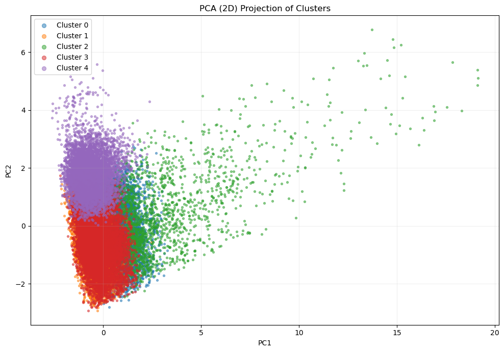

```python
# --- 2) Plot ---
import matplotlib.pyplot as plt

plt.figure(figsize=(10, 7))

for c in sorted(pdf["cluster"].unique()):
    sub = pdf[pdf["cluster"] == c]
    plt.scatter(sub["pc1"], sub["pc2"], s=8, alpha=0.5, label=f"Cluster {c}")

plt.title("PCA (2D) Projection of Clusters")
plt.xlabel("PC1")
plt.ylabel("PC2")
plt.legend(markerscale=2, frameon=True)
plt.grid(True, alpha=0.2)
plt.tight_layout()
plt.show()
```

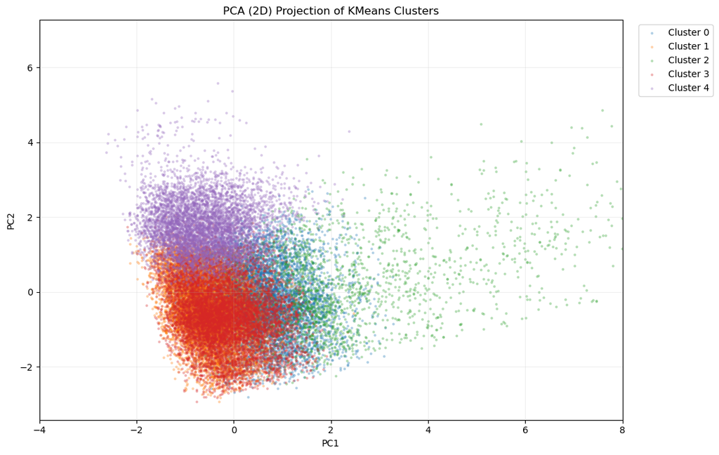

```python
import matplotlib.pyplot as plt

plt.figure(figsize=(11, 7))

for c in sorted(pdf["cluster"].unique()):
    sub = pdf[pdf["cluster"] == c]
    plt.scatter(sub["pc1"], sub["pc2"], s=4, alpha=0.25, label=f"Cluster {c}")

plt.title("PCA (2D) Projection of KMeans Clusters")
plt.xlabel("PC1")
plt.ylabel("PC2")
plt.grid(True, alpha=0.2)
plt.legend(bbox_to_anchor=(1.02, 1), loc="upper left", frameon=True)

plt.xlim(-4, 8)   # adjust left bound if you want

plt.tight_layout()
plt.show()
```

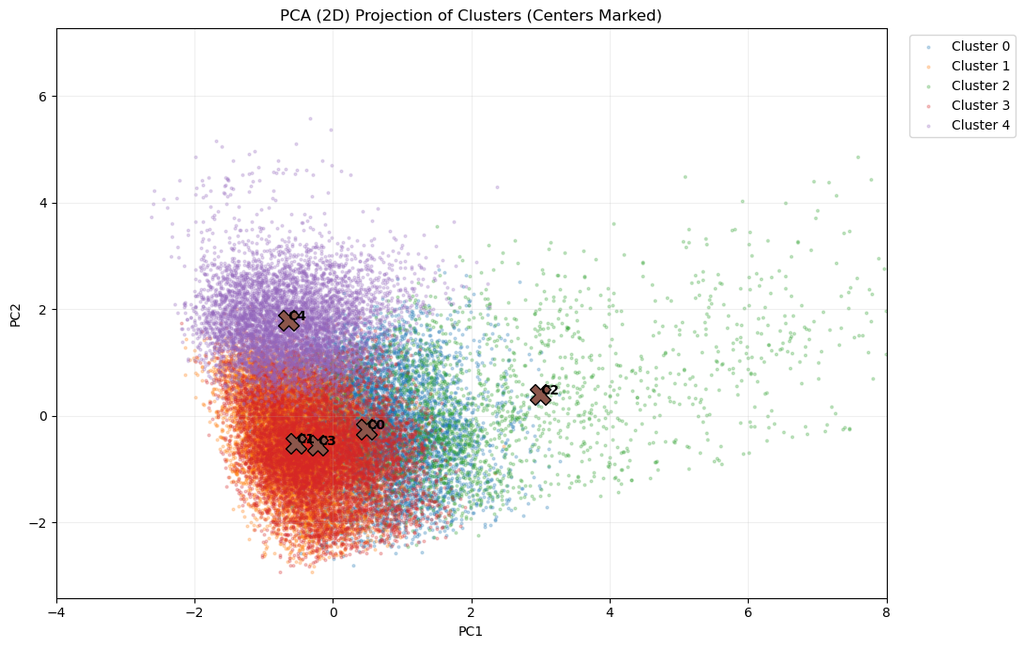

```python
cent = (pdf.groupby("cluster")[["pc1","pc2"]].mean().reset_index())

plt.figure(figsize=(11, 7))
for c in sorted(pdf["cluster"].unique()):
    sub = pdf[pdf["cluster"] == c]
    plt.scatter(sub["pc1"], sub["pc2"], s=4, alpha=0.25, label=f"Cluster {c}")

# overlay centers
plt.scatter(cent["pc1"], cent["pc2"], s=250, marker="X", edgecolors="black", linewidths=1)

for _, r in cent.iterrows():
    plt.text(r["pc1"], r["pc2"], f"C{int(r['cluster'])}", fontsize=10, weight="bold")

plt.title("PCA (2D) Projection of Clusters (Centers Marked)")
plt.xlabel("PC1"); plt.ylabel("PC2")
plt.grid(True, alpha=0.2)
plt.legend(bbox_to_anchor=(1.02, 1), loc="upper left", frameon=True)

plt.xlim(-4, 8)   # adjust left bound if you want
plt.tight_layout()
plt.show()
```

# Profiling

```python
profile_exprs = [F.avg(F.col(c).cast("double")).alias(f"avg_{c}") for c in num_cols]
profile = (df2.groupBy(CLUSTER_COL)
           .agg(F.count("*").alias("n"),
                F.avg("intra_cluster_distance").alias("avg_intra_dist"),
                *profile_exprs)
           .orderBy(CLUSTER_COL))

profile.show(50, truncate=False)

print("Used numeric cols:", num_cols)
```

```
[Stage 2455:============================>                           (1 + 1) / 2]
```

```
+-------+------+------------------+----------------------+-------------------+------------------+-------------------+---------------------+---------------------+-----------------+------------------+-----------------+------------------+------------------+
|cluster|n     |avg_intra_dist    |avg_CONCURRENT_FLIGHTS|avg_NUMBER_OF_SEATS|avg_PLANE_AGE     |avg_PRCP           |avg_SNOW             |avg_SNWD             |avg_TMAX         |avg_AWND          |avg_MONTH        |avg_DAY_OF_WEEK   |avg_DISTANCE_GROUP|
+-------+------+------------------+----------------------+-------------------+------------------+-------------------+---------------------+---------------------+-----------------+------------------+-----------------+------------------+------------------+
|0      |158889|2.807037870649452 |26.949153182410363    |124.65959883944137 |12.30973824493829 |0.09920806349087907|0.005816009918874239 |0.016595862520376075 |57.77958008420971|8.69290215181638  |6.025181101271957|4.005123073340508 |3.1320229845993115|
|1      |167149|2.4137344615783713|28.725741703510042    |125.80146456155884 |12.36033120150285 |0.11160527433608168|0.0                  |0.0                  |85.62052659603108|7.736937223675002 |7.256088878784797|3.9094759765239395|3.1119360570508947|
|2      |39704 |5.098888508605039 |27.58540701188797     |120.8047300020149  |11.591879911343945|0.21817096514205692|0.4775992343340708   |1.3917816844649822   |38.45798911948418|11.475211313721752|4.91965545033246 |3.7575811001410435|3.2831200886560548|
|3      |172490|2.5546327965144715|29.07419560554235     |122.42263899356485 |12.505953968345992|0.08510510754247261|8.290335671633132E-5 |9.739695054785785E-5 |77.11774595628731|7.852860861499324 |6.885065800915995|3.8945098266566176|2.8400718882254044|
|4      |110085|2.578474530447471 |26.00201662351819     |180.8360721260844  |7.623227506018077 |0.08628723259300274|0.0017077712676568093|0.0036208384430212967|72.89799791070536|8.40247009129289  |6.662424490166689|4.020920198028796 |7.599236953263388 |
+-------+------+------------------+----------------------+-------------------+------------------+-------------------+---------------------+---------------------+-----------------+------------------+-----------------+------------------+------------------+

Used numeric cols: ['CONCURRENT_FLIGHTS', 'NUMBER_OF_SEATS', 'PLANE_AGE', 'PRCP', 'SNOW', 'SNWD', 'TMAX', 'AWND', 'MONTH', 'DAY_OF_WEEK', 'DISTANCE_GROUP']
```

## Cluster Narratives (KMeans + PCA + Profiling)

### Cluster 0 — “Typical baseline flights” *(n=158,889)*

- Mid-level congestion (**26.95**), typical aircraft size (**~124.7 seats**) and older fleet (**~12.3 yrs**).
- Mild weather overall (**PRCP 0.099**, tiny snow), moderate temp (**TMAX 57.8**) and wind (**AWND 8.69**).
- Mid-year timing (**Month ~6**) and mid-distance routes (**Dist group 3.13**).

### Cluster 1 — “Hot & dry operations” *(n=167,149)*

- More congested (**28.73**) with typical aircraft (**~125.8 seats**) and older fleet (**~12.36 yrs**).
- Completely snow-free (**SNOW 0**, **SNWD 0**) and hottest conditions (**TMAX 85.6**) with moderate wind (**7.74**).
- Skews later in the year (**Month ~7.26**).

### Cluster 2 — “Winter storm / disruption regime” *(n=39,704)*

- Smallest but most variable cluster (**avg intra-dist 5.10**).
- Strongest weather severity: highest precip (**0.218**), heavy snow (**0.478**) and snow depth (**1.392**), coldest temps (**TMAX 38.5**) and highest wind (**11.48**).
- Earlier-year timing (**Month ~4.92**). This is the **high-risk conditions** regime that separates clearly in PCA.

### Cluster 3 — “Warm, low-snow, shorter routes” *(n=172,490)*

- Highest congestion (**29.07**) with typical seats (**~122.4**) and older planes (**~12.51 yrs**).
- Near-zero snow, warm temps (**TMAX 77.1**), lower precip (**0.085**).
- Slightly shorter routes (**Dist group 2.84**) and mid-to-late year timing (**Month ~6.89**).

### Cluster 4 — “Long-haul / large aircraft / newer fleet” *(n=110,085)*

- Lower congestion (**26.00**) but much larger planes (**~180.8 seats**) and newer fleet (**~7.62 yrs**).
- Low precip and minimal snow, warm temps (**TMAX 72.9**).
- Very long routes (**Dist group 7.60**). This is the distinct **big-plane long-haul** segment.

PCA points + profiling to GCS

```python
OUT_BASE = "gs://big-data-project-481305-flightdelay/airline/clustering/kmeans_k5/report_outputs/"

# PCA points (sample to keep file smaller)
(vis.select("pc1","pc2",F.col(CLUSTER_COL).alias("cluster"),"intra_cluster_distance")
    .sample(False, 0.05, seed=42)   # 5% sample for plotting
    .write.mode("overwrite").parquet(OUT_BASE + "pca_points_5pct/"))

# Profiling table
profile.write.mode("overwrite").csv(OUT_BASE + "cluster_profile_csv/", header=True)

print("Saved to:", OUT_BASE)
```

```
Saved to: gs://big-data-project-481305-flightdelay/airline/clustering/kmeans_k5/report_outputs/
```

Cluster compactness ranking (best/worst clusters)

```python
cluster_quality = (df2.groupBy(CLUSTER_COL)
    .agg(F.count("*").alias("n"),
         F.avg("intra_cluster_distance").alias("avg_dist"),
         F.expr("percentile_approx(intra_cluster_distance, 0.5)").alias("median_dist"),
         F.expr("percentile_approx(intra_cluster_distance, 0.9)").alias("p90_dist"))
    .orderBy(F.desc("avg_dist")))

cluster_quality.show(50, truncate=False)
```

```
[Stage 2485:============================>                           (1 + 1) / 2]
```

```
+-------+------+------------------+------------------+------------------+
|cluster|n     |avg_dist          |median_dist       |p90_dist          |
+-------+------+------------------+------------------+------------------+
|2      |39704 |5.098888508605039 |3.9678593646807347|8.56074315931066  |
|0      |158889|2.807037870649452 |2.735375847320493 |3.5786260868166844|
|4      |110085|2.578474530447471 |2.4830851991292273|3.4656515350644326|
|3      |172490|2.5546327965144715|2.486532835625391 |3.3508074165588884|
|1      |167149|2.4137344615783713|2.301624742066884 |3.1908498808820354|
+-------+------+------------------+------------------+------------------+
```

Explaining the clusters from profiling output

Based on table:

- Cluster 2:

  Highest intra distance (~5.10) → most “mixed” cluster Highest PRCP (0.218) + highest SNOW (0.478) + highest SNWD (1.392) Lowest TMAX (38.46) + highest AWND (11.48)

Interpretation: “Severe winter weather / windy conditions cluster (high variability).”

- Cluster 1:

  Lowest intra distance (2.41) → most compact cluster PRCP (0.112), SNOW = 0, SNWD = 0, TMAX high (85.62)

Interpretation: “Clear-weather warm-season cluster (stable operations).”

- Cluster 4:

  Very high seat count (180.84) + lowest plane age (7.62) distance group much larger (7.60)

Interpretation: “Longer-haul / larger aircraft segment (structurally different fleet/route).”

- Cluster 0 & 3:

Interpretation: “Normal operations clusters split by seasonal temperature/precip regime.”

# Analysis of Cluster Visualization (PCA Projection)**

The 2D Principal Component Analysis (PCA) projection reveals three distinct operational patterns within the flight data:

> **Project Meaning:** The clustering algorithm is successfully isolating the **high-risk weather regime**. This is a critical validation for the project, confirming that the model can distinguish "disruption days" from standard operations without supervision.

**2. Normal Operations & Structural Overlap (Clusters 0, 1, 3)** *Observation:** Clusters 0, 1, and 3 overlap heavily near the origin (approx. $PC1 \in [-1, 1]$ and $PC2 \in [-2, 2]$).

- *Interpretation:** These groups represent **"Normal Operations"** where differences are subtler. While K-Means separates them based on the full high-dimensional feature space, they appear mixed in 2D because PCA only displays the top two directions of variance.

> **Project Meaning:** The visual overlap is **not a failure**; it is a known limitation of 2D PCA projections. These clusters likely represent valid segments based on fleet, route, or time patterns that do not manifest as extreme outliers in the top two principal components.

**3. The Long-Haul / Large Fleet Segment (Cluster 4 – Purple)** *Observation:** Cluster 4 is distinct due to its vertical separation, sitting significantly higher on the PC2 axis.

- *Interpretation:** This vertical shift indicates a difference in **structural patterns** rather than weather severity. Based on feature profiling, Cluster 4 is characterized by:
  - Very high `NUMBER_OF_SEATS`
  - Lower `PLANE_AGE`
  - Much larger `DISTANCE_GROUP`
  - *Summary:* A segment for larger aircraft and long-haul operations.

> **Project Meaning:** This identifies a valuable business segment. **Long-haul and large-aircraft operations** behave differently logistically, implying their delay risk patterns will differ from regional flights. Segregating this group allows the model to learn these specific nuances.

# Project Impact: Why Clustering Matters

# Anomaly Detection (Spikes)

7.1 Build one “scored” dataset across all months (train+val+test)

```python
from pyspark.sql import functions as F

BEST_MODEL_NAME = "GBT"       # change label only
best_model = gbt_model        # or rf_model if RF is best

# union all splits so anomalies can be seen over months 1..12
all_gold = (train5.withColumn("split", F.lit("train"))
            .unionByName(val5.withColumn("split", F.lit("val")))
            .unionByName(test5.withColumn("split", F.lit("test"))))

# apply feature pipeline to all rows
all_fe = feat_model.transform(all_gold)

# score and keep slice columns
scored_all = (add_prob(best_model.transform(
                all_fe.select(
                    "row_id","split",
                    "MONTH","DEP_TIME_BLK",
                    "DEPARTING_AIRPORT_BKT","CARRIER_NAME_BKT",
                    "label","weight","features"
                )
            ))
            .select(
                "row_id","split",
                "MONTH","DEP_TIME_BLK",
                "DEPARTING_AIRPORT_BKT","CARRIER_NAME_BKT",
                "label","p1"
            )
            .cache())

_ = scored_all.count()
print("scored_all rows:", scored_all.count())
scored_all.show(5, truncate=False)
```

```
scored_all rows: 6489062
+--------------------+-----+-----+------------+---------------------+----------------------+-----+-------------------+
|row_id              |split|MONTH|DEP_TIME_BLK|DEPARTING_AIRPORT_BKT|CARRIER_NAME_BKT      |label|p1                 |
+--------------------+-----+-----+------------+---------------------+----------------------+-----+-------------------+
|-5972261017086745821|train|4    |2100-2159   |Atlanta Municipal    |Southwest Airlines Co.|0    |0.6227855461130568 |
|-5147052611826786705|train|4    |1400-1459   |Atlanta Municipal    |Southwest Airlines Co.|0    |0.48472440096180003|
|5853433762726780349 |train|4    |1400-1459   |Atlanta Municipal    |Southwest Airlines Co.|1    |0.5864889478170792 |
|2825730802779138287 |train|4    |1500-1559   |Atlanta Municipal    |Southwest Airlines Co.|1    |0.570769747324567  |
|-6565439843932954386|train|4    |1900-1959   |Atlanta Municipal    |Southwest Airlines Co.|0    |0.6934541792332786 |
+--------------------+-----+-----+------------+---------------------+----------------------+-----+-------------------+
only showing top 5 rows
```

7.2 Aggregate “risk signals” we want to monitor

```python
# Monthly drift proxy (simple, powerful for report)
monthly = (scored_all.groupBy("MONTH")
           .agg(F.count("*").alias("n"),
                F.avg(F.col("label").cast("double")).alias("delay_rate"),
                F.avg("p1").alias("avg_pred_risk"))
           .orderBy("MONTH"))

# Month x timeblock (heatmap + spike detection)
mtb = (scored_all.groupBy("MONTH","DEP_TIME_BLK")
       .agg(F.count("*").alias("n"),
            F.avg(F.col("label").cast("double")).alias("delay_rate"),
            F.avg("p1").alias("avg_pred_risk")))

# Month x airport (spike table; filter small groups to avoid noise)
mair = (scored_all.groupBy("MONTH","DEPARTING_AIRPORT_BKT")
        .agg(F.count("*").alias("n"),
             F.avg(F.col("label").cast("double")).alias("delay_rate"),
             F.avg("p1").alias("avg_pred_risk"))
        .filter(F.col("n") >= 500))

monthly.show(20, truncate=False)
```

```
[Stage 2497:==================================================>   (16 + 1) / 17]
```

```
+-----+------+-------------------+-------------------+
|MONTH|n     |delay_rate         |avg_pred_risk      |
+-----+------+-------------------+-------------------+
|1    |502050|0.1746479434319291 |0.4317398087391284 |
|2    |451439|0.217163337682389  |0.48809878114682964|
|3    |554120|0.17431061863856204|0.43295785171447504|
|4    |533687|0.1850466659296554 |0.4451906656504797 |
|5    |558025|0.20344966623359168|0.47048545570826233|
|6    |557027|0.24392174885598006|0.5170444236055695 |
|7    |578193|0.21314336216453675|0.47985311302454253|
|8    |579532|0.20604729333324132|0.472190795745952  |
|9    |529873|0.13745557897835897|0.3725695110580066 |
|10   |561327|0.16166156268984033|0.4527788369594177 |
|11   |531893|0.1420887283720598 |0.41532657461756595|
|12   |551896|0.208551973560236  |0.4279210620480371 |
+-----+------+-------------------+-------------------+
```

7.3 Spike scoring (robust z-score) + visuals (Matplotlib)

Core anomaly logic:

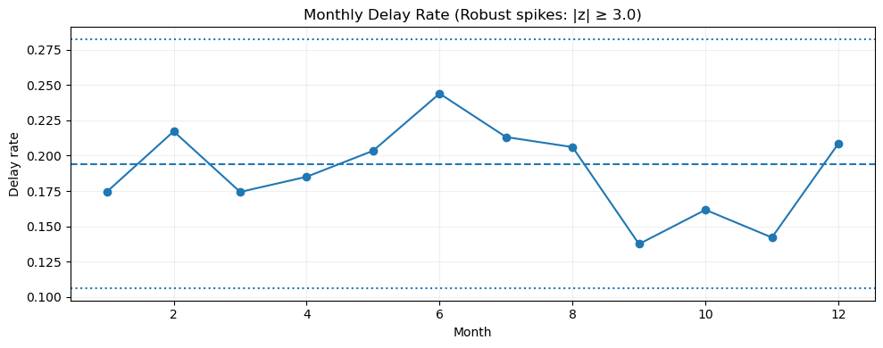

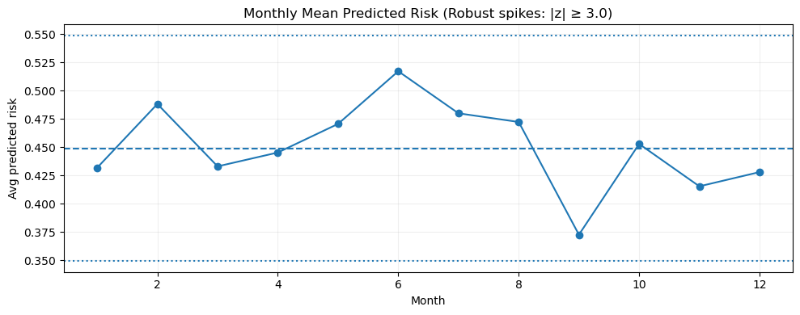

```
Spike months (delay_rate): []
Spike months (avg_pred_risk): []
```

```python
import numpy as np
import pandas as pd
import matplotlib.pyplot as plt

def robust_z(series):
    """Robust z-score using median + MAD."""
    s = np.asarray(series, dtype=float)
    med = np.median(s)
    mad = np.median(np.abs(s - med)) + 1e-9
    z = 0.6745 * (s - med) / mad
    return z, med, mad

Z_THR = 3.0   # robust spike threshold (3.5 is common)

# -----------------------------
# A) Monthly drift/spike plots
# -----------------------------
pdf_m = monthly.toPandas().sort_values("MONTH")

# Robust z + stats for delay rate
z_delay, med_delay, mad_delay = robust_z(pdf_m["delay_rate"].values)
pdf_m["z_delay"] = z_delay
pdf_m["anomaly_delay"] = np.abs(pdf_m["z_delay"]) >= Z_THR

# Robust z + stats for avg predicted risk
z_risk, med_risk, mad_risk = robust_z(pdf_m["avg_pred_risk"].values)
pdf_m["z_risk"] = z_risk
pdf_m["anomaly_risk"] = np.abs(pdf_m["z_risk"]) >= Z_THR

# Convert Z_THR into value-threshold bands for easy plotting:
# z = 0.6745*(x-med)/mad  =>  x = med + (z*mad)/0.6745
def z_to_value_band(med, mad, zthr):
    delta = (zthr * mad) / 0.6745
    return (med - delta, med + delta)

delay_lo, delay_hi = z_to_value_band(med_delay, mad_delay, Z_THR)
risk_lo,  risk_hi  = z_to_value_band(med_risk,  mad_risk,  Z_THR)

# ---- Plot 1: Monthly Delay Rate ----
plt.figure(figsize=(10,4))
plt.plot(pdf_m["MONTH"], pdf_m["delay_rate"], marker="o")

# baseline + bands
plt.axhline(med_delay, linestyle="--")
plt.axhline(delay_hi, linestyle=":")
plt.axhline(delay_lo, linestyle=":")

# spike markers
sp = pdf_m[pdf_m["anomaly_delay"]]
plt.scatter(sp["MONTH"], sp["delay_rate"], s=120, marker="X")

# label spike months only
for _, r in sp.iterrows():
    plt.annotate(f"M{int(r['MONTH'])}", (r["MONTH"], r["delay_rate"]),
                 textcoords="offset points", xytext=(6,6))

plt.title(f"Monthly Delay Rate (Robust spikes: |z| ≥ {Z_THR})")
plt.xlabel("Month"); plt.ylabel("Delay rate")
plt.grid(True, alpha=0.2)
plt.tight_layout()
plt.show()

# ---- Plot 2: Monthly Mean Predicted Risk ----
plt.figure(figsize=(10,4))
plt.plot(pdf_m["MONTH"], pdf_m["avg_pred_risk"], marker="o")

# baseline + bands
plt.axhline(med_risk, linestyle="--")
plt.axhline(risk_hi, linestyle=":")
plt.axhline(risk_lo, linestyle=":")

# spike markers
sp = pdf_m[pdf_m["anomaly_risk"]]
plt.scatter(sp["MONTH"], sp["avg_pred_risk"], s=120, marker="X")

# label spike months only
for _, r in sp.iterrows():
    plt.annotate(f"M{int(r['MONTH'])}", (r["MONTH"], r["avg_pred_risk"]),
                 textcoords="offset points", xytext=(6,6))

plt.title(f"Monthly Mean Predicted Risk (Robust spikes: |z| ≥ {Z_THR})")
plt.xlabel("Month"); plt.ylabel("Avg predicted risk")
plt.grid(True, alpha=0.2)
plt.tight_layout()
plt.show()

# Optional: print which months were flagged (nice for report)
print("Spike months (delay_rate):", sorted(pdf_m.loc[pdf_m["anomaly_delay"], "MONTH"].tolist()))
print("Spike months (avg_pred_risk):", sorted(pdf_m.loc[pdf_m["anomaly_risk"], "MONTH"].tolist()))
```

```
Monthly charts:
```

- These plots show how the actual delay rate and the model’s average predicted delay risk change month-by-month, making seasonal spikes easy to spot.
- Months where both rise together indicate true operational stress periods (weather/traffic), not just model noise.

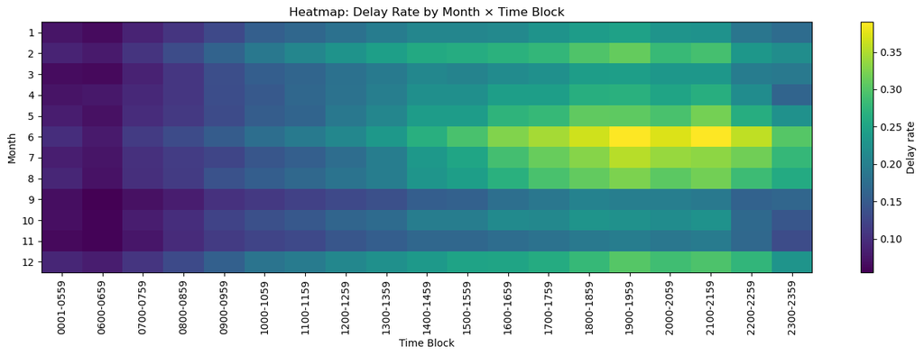

```
Top Month×TimeBlock spikes (within-block robust z):
```

|  | MONTH | DEP_TIME_BLK | n | delay_rate | avg_pred_risk | z_delay_blk |
| --- | --- | --- | --- | --- | --- | --- |
| 173 | 2 | 1200-1259 | 27965 | 0.226569 | 0.500811 | 2.512108 |
| 153 | 9 | 1200-1259 | 32231 | 0.128727 | 0.368000 | -2.864566 |
| 156 | 9 | 1400-1459 | 31114 | 0.154850 | 0.416611 | -2.886929 |

```python
# 1. LINK: Convert  Spark 'mtb' to Pandas 'pdf_mtb'
pdf_mtb = mtb.toPandas()

# 2. RUN VISUALIZATION
import numpy as np
import pandas as pd
import matplotlib.pyplot as plt

def dep_blk_start(s):
    try:
        return int(str(s).split("-")[0])
    except:
        return 9999

# IMPORTANT: return a SAME-LENGTH pandas Series (no length mismatch)
def robust_z_series(s: pd.Series) -> pd.Series:
    x = pd.to_numeric(s, errors="coerce").astype(float)
    med = np.nanmedian(x)
    mad = np.nanmedian(np.abs(x - med))
    if not np.isfinite(mad) or mad == 0:
        return pd.Series(np.zeros(len(x)), index=s.index)   # no variation => z = 0
    z = 0.6745 * (x - med) / mad
    z = np.nan_to_num(z, nan=0.0, posinf=0.0, neginf=0.0)
    return pd.Series(z, index=s.index)

Z_THR = 2.5   # start here; raise/lower later
MIN_N = 300   # ignore tiny cells (noise)

# ---- Prepare month x timeblock table ----
pdf_mtb2 = pdf_mtb.copy()
pdf_mtb2["blk_start"] = pdf_mtb2["DEP_TIME_BLK"].apply(dep_blk_start)

# enforce numeric
pdf_mtb2["delay_rate"] = pd.to_numeric(pdf_mtb2["delay_rate"], errors="coerce")
pdf_mtb2["avg_pred_risk"] = pd.to_numeric(pdf_mtb2["avg_pred_risk"], errors="coerce")
pdf_mtb2["n"] = pd.to_numeric(pdf_mtb2["n"], errors="coerce").fillna(0).astype(int)

# robust z-score WITHIN each timeblock across months (baseline per timeblock)
pdf_mtb2["z_delay_blk"] = (
    pdf_mtb2.groupby("DEP_TIME_BLK")["delay_rate"]
    .transform(robust_z_series)
)

# spike flag: large enough support + z above threshold
pdf_mtb2["is_spike"] = (pdf_mtb2["n"] >= MIN_N) & (pdf_mtb2["z_delay_blk"].abs() >= Z_THR)

# ---- Heatmap matrix (delay_rate) ----
heat = (
    pdf_mtb2.pivot_table(index="MONTH", columns="DEP_TIME_BLK", values="delay_rate", aggfunc="mean")
    .sort_index()
)

# sort columns by start time
cols_sorted = sorted(list(heat.columns), key=dep_blk_start)
heat = heat[cols_sorted]

plt.figure(figsize=(14, 5))
plt.imshow(heat.values, aspect="auto", interpolation="nearest")
plt.xticks(range(len(heat.columns)), heat.columns, rotation=90)
plt.yticks(range(len(heat.index)), heat.index)
plt.title("Heatmap: Delay Rate by Month × Time Block")
plt.xlabel("Time Block")
plt.ylabel("Month")
plt.colorbar(label="Delay rate")
plt.tight_layout()
plt.show()

# ---- Top spikes table (for reporting) ----
top_spikes = (
    pdf_mtb2[pdf_mtb2["is_spike"]]
    .sort_values("z_delay_blk", ascending=False)
    .loc[:, ["MONTH","DEP_TIME_BLK","n","delay_rate","avg_pred_risk","z_delay_blk"]]
    .head(15)
)

print("Top Month×TimeBlock spikes (within-block robust z):")
display(top_spikes)

if top_spikes.empty:
    print("No spikes at current threshold. Showing top 15 most unusual cells anyway:")
    display(
        pdf_mtb2[pdf_mtb2["n"] >= MIN_N]
        .sort_values("z_delay_blk", ascending=False)
        .loc[:, ["MONTH","DEP_TIME_BLK","n","delay_rate","avg_pred_risk","z_delay_blk"]]
        .head(15)
    )
```

```
Month × Time Block heatmap:
```

# Where did the spikes come from?” (airport/carrier drivers)

This produces a bar chart of the most anomalous airports (per-month vs that airport’s normal).

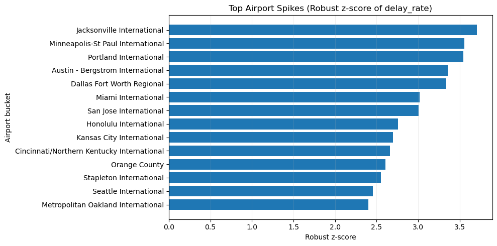

|  | MONTH | DEPARTING_AIRPORT_BKT | n | delay_rate | avg_pred_risk | z_delay |
| --- | --- | --- | --- | --- | --- | --- |
| 541 | 6 | Jacksonville International | 2965 | 0.220236 | 0.475167 | 3.707612 |
| 249 | 7 | Jacksonville International | 2983 | 0.218572 | 0.446957 | 3.615468 |
| 404 | 2 | Minneapolis-St Paul International | 10714 | 0.246873 | 0.467395 | 3.556016 |
| 209 | 2 | Portland International | 4166 | 0.170667 | 0.394542 | 3.541102 |
| 604 | 6 | Austin - Bergstrom International | 5711 | 0.256172 | 0.514768 | 3.357702 |
| 141 | 12 | Portland International | 5353 | 0.167756 | 0.328853 | 3.347147 |
| 509 | 6 | Dallas Fort Worth Regional | 25390 | 0.301457 | 0.587911 | 3.335809 |
| 580 | 8 | Miami International | 7209 | 0.296851 | 0.553475 | 3.017594 |
| 122 | 12 | San Jose International | 5195 | 0.211935 | 0.365916 | 3.002828 |
| 428 | 2 | Honolulu International | 3491 | 0.141793 | 0.323024 | 2.755833 |
| 597 | 6 | Kansas City International | 4615 | 0.214518 | 0.466575 | 2.699255 |
| 566 | 5 | Dallas Fort Worth Regional | 25360 | 0.285607 | 0.559640 | 2.674216 |
| 503 | 6 | Cincinnati/Northern Kentucky International | 4183 | 0.258905 | 0.523423 | 2.657504 |
| 182 | 2 | Orange County | 3031 | 0.211151 | 0.438970 | 2.606167 |
| 530 | 6 | Stapleton International | 21878 | 0.332663 | 0.598706 | 2.550186 |
| 188 | 8 | Jacksonville International | 2891 | 0.199239 | 0.443317 | 2.545028 |
| 180 | 2 | Seattle International | 9017 | 0.241433 | 0.505450 | 2.454532 |
| 564 | 6 | Miami International | 7008 | 0.274115 | 0.573604 | 2.451173 |
| 510 | 6 | Portland International | 5529 | 0.154097 | 0.375383 | 2.436991 |
| 94 | 12 | Metropolitan Oakland International | 4387 | 0.336221 | 0.433369 | 2.399849 |

```python
pdf_air = mair.toPandas()

# spike vs that airport’s baseline across months
pdf_air["z_delay"] = (pdf_air.groupby("DEPARTING_AIRPORT_BKT")["delay_rate"]
                      .transform(lambda x: robust_z(x.values)[0]))
pdf_air["is_spike"] = (np.abs(pdf_air["z_delay"]) >= Z_THR)

# take strongest positive spikes
top_air_spikes = (pdf_air.sort_values("z_delay", ascending=False)
                  .head(20))

plt.figure(figsize=(10,5))
plt.barh(top_air_spikes["DEPARTING_AIRPORT_BKT"].astype(str),
         top_air_spikes["z_delay"])
plt.title("Top Airport Spikes (Robust z-score of delay_rate)")
plt.xlabel("Robust z-score"); plt.ylabel("Airport bucket")
plt.gca().invert_yaxis()
plt.grid(True, axis="x", alpha=0.2)
plt.tight_layout()
plt.show()

display(top_air_spikes[["MONTH","DEPARTING_AIRPORT_BKT","n","delay_rate","avg_pred_risk","z_delay"]].head(20))
```

Export all Phase outputs to GCS (Parquet + CSV)

```python
from datetime import datetime
import pandas as pd

run_id = datetime.utcnow().strftime("%Y%m%d_%H%M%S")
OUT_BASE = f"gs://big-data-project-481305-flightdelay/airline/anomalies/run_{run_id}/"
print("Writing to:", OUT_BASE)

# Save raw aggregates (Spark DFs)
monthly.write.mode("overwrite").parquet(OUT_BASE + "monthly_parquet/")
mtb.write.mode("overwrite").parquet(OUT_BASE + "month_timeblock_parquet/")
mair.write.mode("overwrite").parquet(OUT_BASE + "month_airport_parquet/")

# Save spike tables (Pandas -> Spark), but guard against empty
def safe_export_pdf(pdf: pd.DataFrame, path: str):
    if pdf is None or len(pdf) == 0:
        spark.createDataFrame([], "MONTH int, DEP_TIME_BLK string, n int, delay_rate double, avg_pred_risk double, z_delay_blk double") \
            .coalesce(1).write.mode("overwrite").csv(path, header=True)
        print("Exported EMPTY placeholder:", path)
    else:
        spark.createDataFrame(pdf).coalesce(1).write.mode("overwrite").csv(path, header=True)
        print("Exported:", path)

# Month×TimeBlock spikes table you just fixed (top_spikes)
safe_export_pdf(top_spikes, OUT_BASE + "top_spikes_month_timeblock_csv/")

# If you also have top_air_spikes (month×airport)
if "top_air_spikes" in globals():
    safe_export_pdf(top_air_spikes, OUT_BASE + "top_spikes_month_airport_csv/")

print("Done. Phase-7 anomalies exported to:", OUT_BASE)
```

```
Writing to: gs://big-data-project-481305-flightdelay/airline/anomalies/run_20251221_035448/
```

```
Exported: gs://big-data-project-481305-flightdelay/airline/anomalies/run_20251221_035448/top_spikes_month_timeblock_csv/
```

```
Exported: gs://big-data-project-481305-flightdelay/airline/anomalies/run_20251221_035448/top_spikes_month_airport_csv/
Done. Phase-7 anomalies exported to: gs://big-data-project-481305-flightdelay/airline/anomalies/run_20251221_035448/
```

```python
# --- 6) Export everything to GCS (handles empty spike tables safely) ---
run_id = datetime.utcnow().strftime("%Y%m%d_%H%M%S")
OUT_BASE = f"gs://big-data-project-481305-flightdelay/airline/anomalies/run_{run_id}/"
print("Writing to:", OUT_BASE)

monthly.write.mode("overwrite").parquet(OUT_BASE + "monthly_parquet/")
mtb.write.mode("overwrite").parquet(OUT_BASE + "month_timeblock_parquet/")
mair.write.mode("overwrite").parquet(OUT_BASE + "month_airport_parquet/")

def safe_export_pdf(pdf, path, schema_str):
    if pdf is None or len(pdf) == 0:
        spark.createDataFrame([], schema_str).coalesce(1).write.mode("overwrite").csv(path, header=True)
        print("Exported EMPTY placeholder:", path)
    else:
        spark.createDataFrame(pdf).coalesce(1).write.mode("overwrite").csv(path, header=True)
        print("Exported:", path)

safe_export_pdf(
    top_spikes,
    OUT_BASE + "top_spikes_month_timeblock_csv/",
    "MONTH int, DEP_TIME_BLK string, n long, delay_rate double, avg_pred_risk double, z_delay_blk double"
)

safe_export_pdf(
    top_air_spikes,
    OUT_BASE + "top_spikes_month_airport_csv/",
    "MONTH int, DEPARTING_AIRPORT_BKT string, n long, delay_rate double, avg_pred_risk double, z_delay_air double"
)

print("Done. anomalies exported to:", OUT_BASE)
```

```
Writing to: gs://big-data-project-481305-flightdelay/airline/anomalies/run_20251221_035459/
```

```
Exported: gs://big-data-project-481305-flightdelay/airline/anomalies/run_20251221_035459/top_spikes_month_timeblock_csv/
```

[output not shown]

```
Exported: gs://big-data-project-481305-flightdelay/airline/anomalies/run_20251221_035459/top_spikes_month_airport_csv/
Done. anomalies exported to: gs://big-data-project-481305-flightdelay/airline/anomalies/run_20251221_035459/
```

# Scale-IN experiment (10% → 25% → 50% → 100%)

Scaling Strategy: Progressive 'Scale-In'

We adopted a progressive 'Scale-In' strategy to efficiently validate pipeline integrity and optimize hyperparameters. By incrementally increasing data volume, we ensure model stability and resource efficiency before committing to full-scale training.

```python
import time
import pandas as pd
from datetime import datetime
from pyspark.sql import Row
from pyspark.sql import functions as F
from pyspark.ml.classification import GBTClassifier

# ----------------------------
# 0) Helper: timing wrapper
# ----------------------------
def timed(name, fn):
    t0 = time.perf_counter()
    out = fn()
    dt = time.perf_counter() - t0
    print(f"[TIMER] {name}: {dt:.2f}s ({dt/60:.2f}m)")
    return out, dt

# ----------------------------
# 1) PRE-COMPUTE STEP (Run this ONCE before the loop)
# ----------------------------
print("--- PRE-MATERIALIZATION STARTED ---")

# A. Define Columns
CAT_COLS = BASE_CAT
NUM_COLS = BASE_NUM + CONGESTION_NUM + WEATHER_NUM + LEAKAGE_SAFE_AGG

# B. Fit Feature Pipeline ONCE on full training data
# Note: This is acceptable for scale-in experiments. We fit on 100% to get a consistent schema.
raw_feat_model, dt_fit = timed("Fit Feature Pipeline (Full Train)", lambda:
    build_feature_pipeline(CAT_COLS, NUM_COLS).fit(train5)
)

# C. Transform and Cache ALL sets ONCE
# This avoids re-calculating vectors for Val/Test in every loop iteration
def transform_and_cache(df, name):
    out = raw_feat_model.transform(df).select("row_id", "label", "weight", "features").cache()
    count = out.count() # Force materialization
    print(f"Cached {name}: {count} rows")
    return out

train5_fe_all, _ = timed("Transform+Cache Full Train", lambda: transform_and_cache(train5, "Train Full"))
val5_fe, _       = timed("Transform+Cache Val",       lambda: transform_and_cache(val5, "Val"))
test5_fe, _      = timed("Transform+Cache Test",      lambda: transform_and_cache(test5, "Test"))

print("--- PRE-MATERIALIZATION COMPLETE ---")


# ----------------------------
# 2) Optimized Scale-up runner
# ----------------------------
def run_scaleup_fast(frac, tr_full_fe, va_fe, te_fe, seed=42):
    run_id = datetime.utcnow().strftime("%Y%m%d_%H%M%S")

    # 1. Sample from the ALREADY TRANSFORMED training data
    # This is effectively instant compared to re-running the pipeline
    tr_sample = tr_full_fe.sample(False, frac, seed)

    # Force cache on the small sample so the GBT iterates fast
    tr_sample.cache()
    n_sample = tr_sample.count()
    print(f"[{frac:.2f}] Training on {n_sample} rows...")

    # 2. Fit GBT
    def fit_gbt():
        return GBTClassifier(
            featuresCol="features", labelCol="label", weightCol="weight",
            maxIter=80, maxDepth=6, stepSize=0.08, subsamplingRate=0.8
        ).fit(tr_sample)

    gbt_model, dt_fit_model = timed(f"[{frac:.2f}] fit GBT", fit_gbt)

    # 3. Evaluate (Using the pre-cached Validation/Test sets)
    thresholds = [i/100 for i in range(10, 91, 5)]
    (summary, va_pred, te_pred), dt_eval = timed(f"[{frac:.2f}] eval", lambda:
        evaluate_classifier(f"GBT_scaleup_{frac:.2f}", gbt_model, va_fe, te_fe, thresholds=thresholds)
    )

    # 4. Cleanup (Crucial for loops!)
    tr_sample.unpersist()

    # Build results
    out = dict(summary)
    out.update({
        "run_id": run_id,
        "train_frac": float(frac),
        "train_n": n_sample,
        "val_n": va_fe.count(), # Metadata lookup only
        "time_fit_model_s": dt_fit_model,
        "time_eval_s": dt_eval,
        "time_total_s": dt_fit_model + dt_eval # We exclude one-off pipeline time here
    })
    return Row(**out)

# ----------------------------
# 3) Run scale-up grid
# ----------------------------
SCALE_FRACS = [0.10, 0.25, 0.50, 1.00]

# Pass the PRE-TRANSFORMED dataframes into the function
scaleup_rows = [run_scaleup_fast(fr, train5_fe_all, val5_fe, test5_fe) for fr in SCALE_FRACS]

scaleup_df = spark.createDataFrame(scaleup_rows)

scaleup_df.select(
    "train_frac","train_n",
    "val_pr_auc","test_pr_auc",
    "test_recall_top5","test_f1",
    "time_total_s","time_fit_model_s"
).orderBy("train_frac").show(truncate=False)
```

```
--- PRE-MATERIALIZATION STARTED ---
```

```
[TIMER] Fit Feature Pipeline (Full Train): 57.33s (0.96m)
```

[output not shown]

```
Cached Train Full: 4843946 rows
[TIMER] Transform+Cache Full Train: 90.16s (1.50m)
```

```
Cached Val: 561327 rows
[TIMER] Transform+Cache Val: 5.27s (0.09m)
```

```
Cached Test: 1083789 rows
[TIMER] Transform+Cache Test: 18.87s (0.31m)
--- PRE-MATERIALIZATION COMPLETE ---
```

```
[0.10] Training on 484127 rows...
```

```
[TIMER] [0.10] fit GBT: 226.01s (3.77m)
```

[output not shown]

```
[TIMER] [0.10] eval: 135.56s (2.26m)
```

```
[0.25] Training on 1211860 rows...
```

```
[TIMER] [0.25] fit GBT: 432.76s (7.21m)
```

```
[TIMER] [0.25] eval: 80.07s (1.33m)
```

```
[0.50] Training on 2420529 rows...
```

```
[TIMER] [0.50] fit GBT: 790.32s (13.17m)
```

```
[TIMER] [0.50] eval: 79.88s (1.33m)
```

```
[1.00] Training on 4843946 rows...
```

```
[TIMER] [1.00] fit GBT: 4502.15s (75.04m)
```

```
[TIMER] [1.00] eval: 81.07s (1.35m)
+----------+-------+-------------------+-------------------+-------------------+------------------+-----------------+------------------+
|train_frac|train_n|val_pr_auc         |test_pr_auc        |test_recall_top5   |test_f1           |time_total_s     |time_fit_model_s  |
+----------+-------+-------------------+-------------------+-------------------+------------------+-----------------+------------------+
|0.1       |484127 |0.30528446080904253|0.30925202316826106|0.12355578864560116|0.3613727843533766|361.5605987420022|226.00559578400134|
|0.25      |1211860|0.31132224439603956|0.3178245216725219 |0.12558017569162186|0.3650202070084557|512.8247194660034|432.75778674200046|
|0.5       |2420529|0.31381504462284937|0.31717235765158197|0.12604693850793233|0.3661405765779255|870.2020857069983|790.3183496550009 |
|1.0       |4843946|0.3123123927345366 |0.3173237403078277 |0.12716402255146192|0.3476221542610598|4583.223232972003|4502.151031329002 |
+----------+-------+-------------------+-------------------+-------------------+------------------+-----------------+------------------+
```

```python
# ----------------------------
# 4) SAVE RESULTS (For use in other notebooks)
# ----------------------------

# Method A: Save as a Spark Table (The "In-Memory" persistent way)
# This saves metadata to Hive, allowing any other notebook to query it immediately.
table_name = "bia_scaleup_results"
scaleup_df.write.mode("overwrite").saveAsTable(table_name)
print(f"Saved results to Hive Table: {table_name}")

# Method B: Save as CSV
# .coalesce(1) ensures it writes a single file, not a distributed folder
csv_path = "bia_scaleup_results_csv"
scaleup_df.coalesce(1).write.mode("overwrite").option("header", "true").csv(csv_path)
print(f"Saved results to CSV at: {csv_path}")
```

```
Saved results to Hive Table: bia_scaleup_results
Saved results to CSV at: bia_scaleup_results_csv
```

```python
# 3. Convert Pandas DF -> Spark DF
# This moves the data from local memory to the cluster
spark_df = spark.createDataFrame(pdf_res)

# OPTION A: Save as a Hive Table
table_name = "bia_scaleup_results_recovered"
spark_df.write.mode("overwrite").saveAsTable(table_name)
print(f"Success! Data saved to Hive Table: {table_name}")

# OPTION B: Save to a specific Bucket/Folder
# coalesce(1) to ensure it writes just 1 CSV file, not multiple parts.
save_path = OUT + "recovered_data/scaleup_results"
spark_df.coalesce(1).write.mode("overwrite").option("header", "true").csv(save_path)
print(f"Success! Data saved to Bucket path: {save_path}")
```

```
Success! Data saved to Hive Table: bia_scaleup_results_recovered
```

```
Success! Data saved to Bucket path: gs://big-data-project-481305-flightdelay/airline/final_run_20251221_054405/recovered_data/scaleup_results
```